# M1: Discrete Home Range Estimation

Day 3 — Home Range Estimation

Animal Movement Analyses for Ecologists | SYSU Shenzhen

## Learning Objectives

By the end of this module you will be able to:

1. Explain the difference between discrete (independence-assuming) and continuous-time (autocorrelation-aware) home range estimators, and why the choice matters for biased GPS data
2. Estimate and compare home ranges for one individual using three discrete methods — MCP, LoCoH, and KDE (`amt`) — and articulate what each method assumes and what it gets wrong
3. Scale a single-individual workflow to estimate and compare home range area across an entire population
4. Calculate two additional MoveTraits movement traits that depend on home-range estimation — **range size** and **intensity of use** — across multiple time windows, completing the five-trait set introduced in an earlier module

**Packages used:** `amt`, `sf`, `leaflet`, `RColorBrewer`, `tidyverse`, `lubridate`

## Ecological context: why estimate home ranges, and why more than one method?

A home range is the area an individual uses for its routine activities — foraging, resting, breeding — over a defined period (Burt 1943). Estimating it well matters for almost everything downstream in this workshop: it sets the spatial scale at which habitat selection is meaningful, it’s the denominator against which space-use intensity is judged (Section 5, below), and for a partially-migratory, fence-bound population like the Athi-Kaputiei wildebeest, changes in range size and shape are one of the most direct signals that connectivity has been lost.

**Discrete** methods — MCP, LoCoH, KDE — treat each GPS fix as an independent, identically distributed draw from the animal’s space-use distribution. That assumption is convenient (these estimators are fast, simple, and easy to compare across studies) but it is also usually wrong: modern GPS data are autocorrelated, and ignoring that autocorrelation systematically biases area estimates — usually downward, since correlated fixes are functionally fewer “independent” samples than they appear (Noonan et al. 2019, *Ecological Monographs* 89(2):e01344). Walter, Onorato & Fischer (2015, *Movement Ecology* 3) is a good practical reference for the broader question this raises: there is no single best estimator, and the right choice depends on what the home range estimate will be used for. **Continuous-time** methods — autocorrelated KDE (AKDE) via `ctmm`, covered in a later module — model that autocorrelation explicitly instead of assuming it away. Note that you can also calculate AKDE via `amt` using `hr_akde` function. However, we will first focus on the discrete methods here because they remain the fastest route to a first look at space use, and because understanding what they assume is what makes the autocorrelation-aware alternative legible later.

## This module also closes a loop from an earlier module as we will also learn how to calculate two additional move traits: **range size** and **intensity of use**.

## 1. Setup

### 1.1 Load packages

```r
# install.packages(c("amt", "sf", "leaflet", "RColorBrewer", "tidyverse", "lubridate"))

library(amt)         # Tracks, home-range estimation
library(sf)          # Spatial vector data
library(leaflet)     # Interactive maps
library(RColorBrewer) # Color palettes
library(tidyverse)   # Data wrangling and visualization
library(lubridate)   # Timestamps, floor_date()
```

### 1.2 Rebuild `trk_all`

As before, we rebuild the multi-individual track from the cleaned `move2` data.

```r
load("Data/WB_clean.rdata")   # loads WB.mv2, the cleaned wildebeest track data

latlong_crs <- "EPSG:4326"   # WGS84 geographic — what move2/Movebank gives us
utm_crs     <- "EPSG:32737"  # UTM Zone 37S — metric, needed for area in m^2/km^2

WB_df <- WB.mv2 %>%
  mutate(x = sf::st_coordinates(.)[, 1],
         y = sf::st_coordinates(.)[, 2]) %>%
  as_tibble() %>%
  transmute(id = individual_local_identifier, x, y, t = timestamp) %>%
  arrange(id, t)

trk_all <- make_track(WB_df, x, y, t, id = id, crs = latlong_crs)
trk_all <- transform_coords(trk_all, utm_crs)

trk_nested <- trk_all %>% nest(data = -id)
trk_nested
```

| id | data |
| --- | --- |
| Sotua |  |
| Laingoni |  |
| Ne Mpaash |  |
| Noontare |  |
| Ole Nagol |  |
| Kiranto |  |
| Paita |  |
| Karbolo |  |
| Ntishya |  |
| Peria |  |

[output cut: 2 more lines]

## 2. Home range for one individual: MCP, LoCoH, KDE

```r
one_trk <- trk_all %>% filter(id == "Sotua")
```

### 2.1 MCP (Minimum Convex Polygon)

MCP draws the smallest convex polygon containing a chosen percentage of fixes.

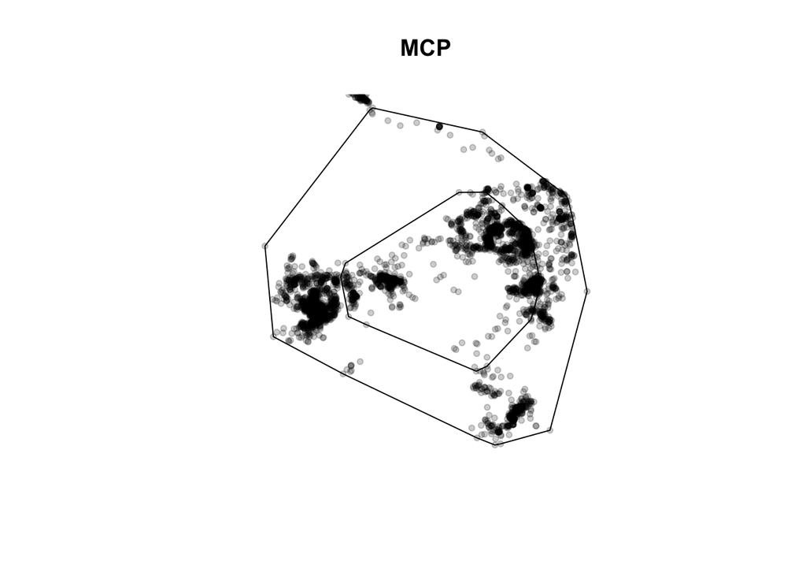

```r
one_mcp <- hr_mcp(one_trk, levels = c(0.5, 0.95))
plot(one_mcp, main = "MCP")
```

MCP is simple and assumes independence between fixes. It also makes no use of fix density — every point inside the polygon counts equally, so it routinely includes large areas the animal rarely or never actually used, and it says nothing about *where* within the range use was concentrated.

### 2.2 LoCoH (Local Convex Hull)

LoCoH builds a local MCP around each fix using its *k* nearest neighbors (or, in other variants, an *r* radius or *a* sum of distances), then unions those local hulls.

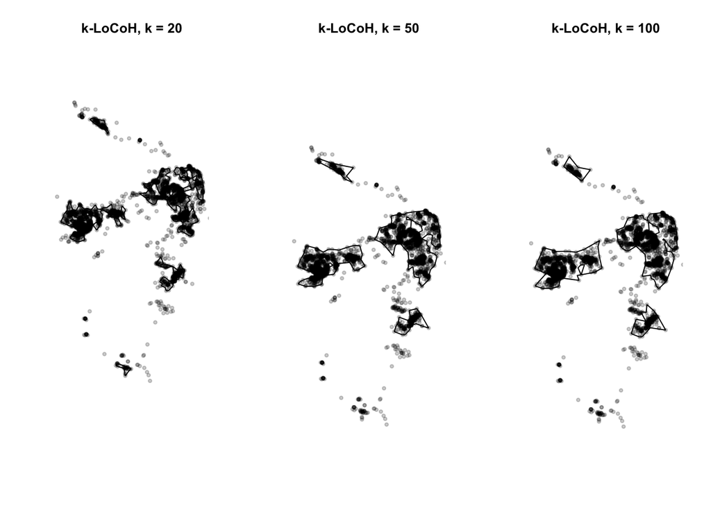

```r
one_locoh_20  <- hr_locoh(one_trk, type = "k", n = 20,  levels = c(0.5, 0.95))
one_locoh_50  <- hr_locoh(one_trk, type = "k", n = 50,  levels = c(0.5, 0.95))
one_locoh_100 <- hr_locoh(one_trk, type = "k", n = 100, levels = c(0.5, 0.95))

par(mfrow = c(1, 3))
plot(one_locoh_20,  main = "k-LoCoH, k = 20")
plot(one_locoh_50,  main = "k-LoCoH, k = 50")
plot(one_locoh_100, main = "k-LoCoH, k = 100")
```

LoCoH accounts for the fact that nearby points are related and excludes areas with no real support in the data — visibly tighter and more irregular than the MCP above. But choosing *k* (or *r*, or *a*) is non-trivial, as the three panels above make clear, and LoCoH still assumes independence between fixes and reasonably regular sampling.

### 2.3 KDE (Kernel Density Estimation)

KDE estimates a smooth utilization distribution — the relative probability of finding the animal at each location — rather than a single hard boundary.

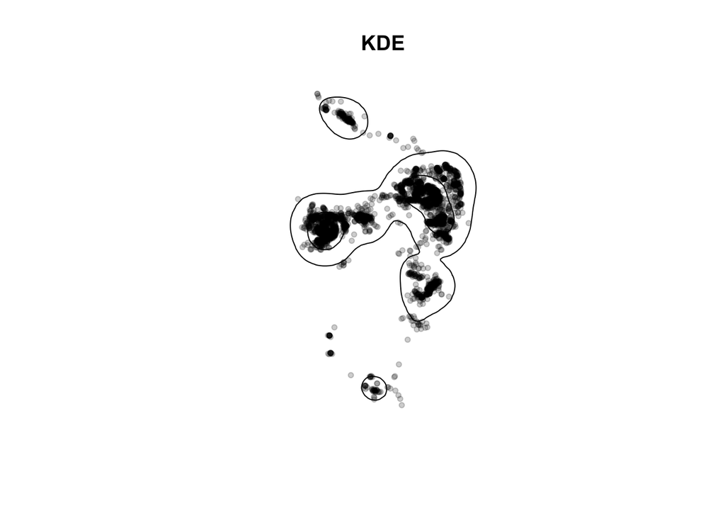

```r
trast   <- make_trast(one_trk, res = 50)   # 50 m resolution raster template, in UTM units
one_kde <- hr_kde(one_trk, trast = trast, levels = c(0.5, 0.95))
plot(one_kde, main = "KDE")
```

KDE still assumes independence and regular sampling, and autocorrelation in real GPS data tends to make it *underestimate* area — exactly the bias Noonan et al. (2019) quantify. That said, these assumptions mattered less when location data were scarce and expensive to collect; KDE’s continuing popularity is partly historical.

> **Note on `levels`:** in all three methods, `levels` sets the isopleth — 95% gives the broad range, 50% the “core” area. Excluding the outer few percent is a deliberate choice to drop one-off outlier forays, but sometimes those rare excursions (a long-distance dispersal attempt, a single crossing of a fence gap) are exactly the behavior you care about. Don’t default to 95%/50% without asking whether your question needs the tails.

### 2.4 Comparing the three estimators

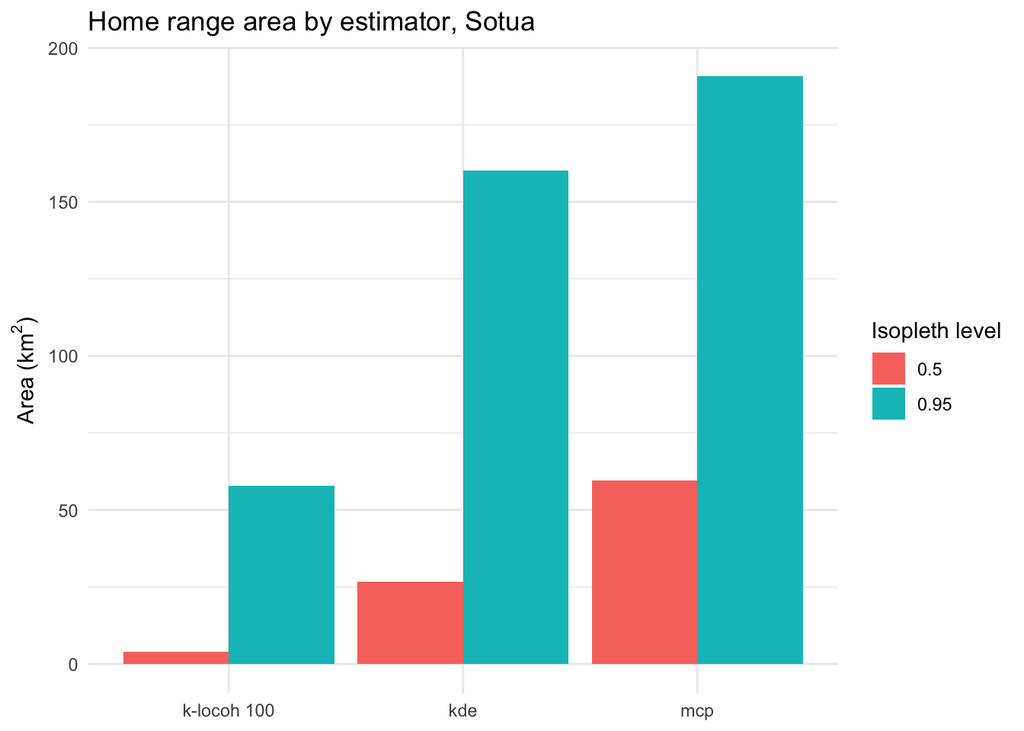

```r
hr_area_one <- cbind(
  tibble(method = rep(c("mcp", "k-locoh 100", "kde"), each = 2)),
  rbind(hr_area(one_mcp), hr_area(one_locoh_100), hr_area(one_kde))
) %>%
  select(-what)

hr_area_one %>%
  ggplot(aes(x = method, y = area / 1e6, group = factor(level), fill = factor(level))) +
  geom_bar(stat = "identity", position = "dodge") +
  theme_minimal() +
  labs(title = "Home range area by estimator, Sotua",
       x = NULL, y = expression("Area ("*km^2*")"), fill = "Isopleth level")
```

> **Discussion:** Before choosing an estimator for your own work, ask what the home range estimate is *for*. A quick, conservative delineation of where an animal could plausibly go is a different goal from a defensible estimate of the core area it relies on most — and those two goals can call for different methods entirely.

## 3. Home range for multiple individuals

Scaling to every individual follows the same nest → map → combine logic used for movement traits in an earlier module, with one wrinkle: `hr_mcp()` returns an `sf` object, not a plain numeric column, so we can’t `unnest()` it directly — we bind the list of `sf` objects together with `bind_rows()` instead.

```r
wb_mcp_nested <- trk_nested %>%
  mutate(mcp = map(data, function(x) {
    mcp <- hr_mcp(x, levels = 0.95)
    return(mcp$mcp)
  }))

wb_mcp <- bind_rows(wb_mcp_nested$mcp) %>%
  mutate(id = wb_mcp_nested$id)

wb_mcp
```

|  | level | what | area | geometry | id |
| --- | --- | --- | --- | --- | --- |
| 1 | 0.95 | estimate | 190698065 [m^2] |  | Sotua |
| 2 | 0.95 | estimate | 78281701 [m^2] |  | Laingoni |
| 3 | 0.95 | estimate | 5342947 [m^2] |  | Ne Mpaash |
| 4 | 0.95 | estimate | 56545522 [m^2] |  | Noontare |
| 5 | 0.95 | estimate | 9672410 [m^2] |  | Ole Nagol |
| 6 | 0.95 | estimate | 75697053 [m^2] |  | Kiranto |
| 7 | 0.95 | estimate | 8314420 [m^2] |  | Paita |
| 8 | 0.95 | estimate | 36336041 [m^2] |  | Karbolo |
| 9 | 0.95 | estimate | 518253015 [m^2] |  | Ntishya |
| 10 | 0.95 | estimate | 260385746 [m^2] |  | Peria |

[output cut: 2 more lines]

> **Try it yourself:** before looking at the chart below, sketch what you’d expect — do you think 95% MCP area will vary a little or a lot across individuals? What’s one fair way to compare them, given that individuals were tracked for different lengths of time?

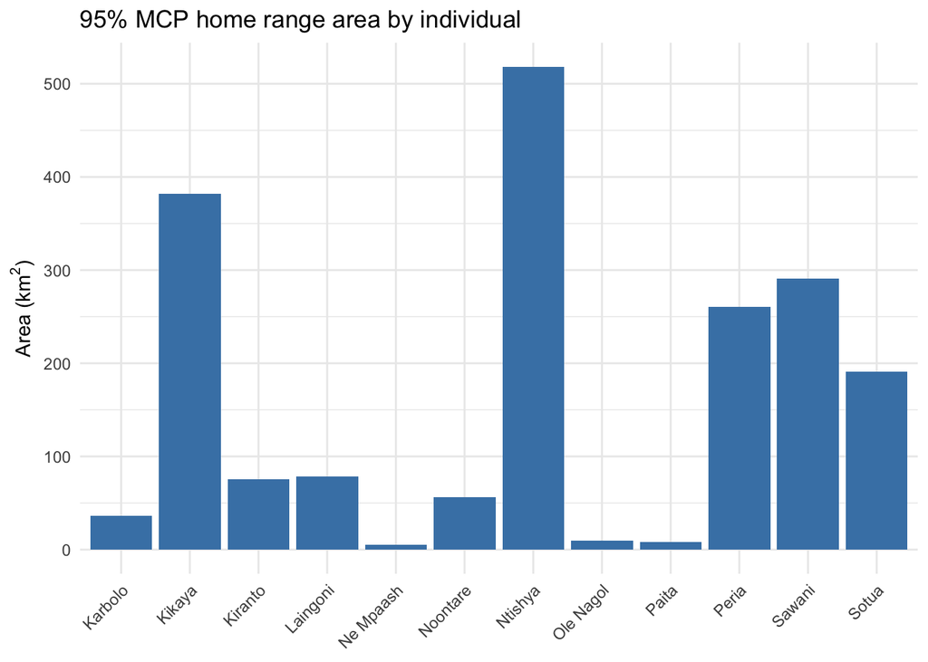

```r
wb_mcp %>%
  ggplot(aes(x = id, y = as.numeric(area) / 1e6)) +
  geom_col(fill = "steelblue") +
  theme_minimal() +
  labs(title = "95% MCP home range area by individual",
       x = NULL, y = expression("Area ("*km^2*")")) +
  theme(axis.text.x = element_text(angle = 45, hjust = 1))
```

> **Discussion:** Home range area computed over an individual’s *entire* track is confounded by tracking duration — an individual tracked for 18 months has simply had more opportunities to visit new places than one tracked for 6, independent of any real difference in ranging behavior. A fairer comparison would standardize by duration (e.g., truncate every track to the same number of days before computing MCP), or compare the **windowed** range-size trait in Section 4 instead, which sidesteps the problem by computing area within fixed-length windows rather than over the whole track.

### 3.1 Mapping all individuals’ home ranges

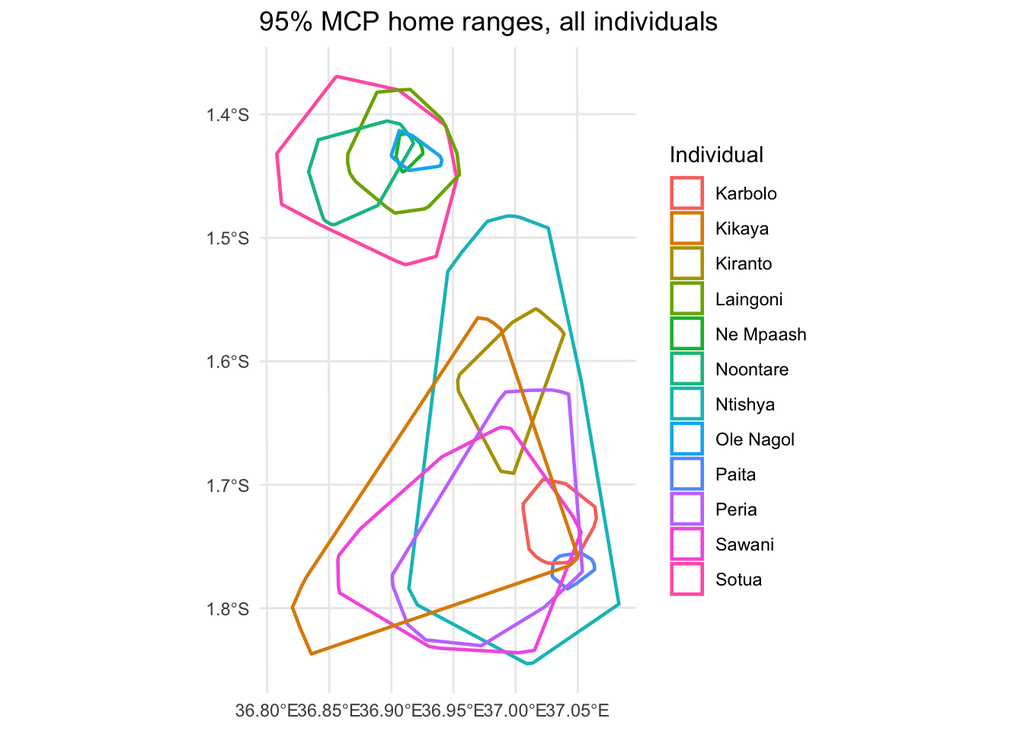

```r
ggplot() +
  geom_sf(data = wb_mcp, aes(color = id), fill = NA, alpha = 0.4, linewidth = 0.8) +
  theme_minimal() +
  labs(title = "95% MCP home ranges, all individuals", color = "Individual")
```

```r
# leaflet only takes lon/lat, so transform back from UTM
wb_mcp_geo <- wb_mcp %>% st_transform(crs = st_crs(4326))

pal <- colorFactor(
  palette = brewer.pal(length(unique(wb_mcp_geo$id)), "Set3"),
  domain  = wb_mcp_geo$id
)

leaflet(wb_mcp_geo) %>%
  addProviderTiles("CartoDB.Positron") %>%
  addPolygons(fillColor = ~pal(id), color = "black", weight = 1,
              opacity = 1, fillOpacity = 0.6,
              popup = ~paste("Animal ID:", id)) %>%
  addLegend("bottomright", pal = pal, values = ~id, title = "Animal ID")
```

[interactive chart not shown]

### 3.2 Exporting results

`sf` objects drop straight to a plain data frame once you no longer need the geometry — useful for reporting or for joining home-range area onto other per-individual tables:

```r
wb_mcp_df <- st_drop_geometry(wb_mcp)
wb_mcp_df
```

|  | level | what | area | id |
| --- | --- | --- | --- | --- |
| 1 | 0.95 | estimate | 190698065 [m^2] | Sotua |
| 2 | 0.95 | estimate | 78281701 [m^2] | Laingoni |
| 3 | 0.95 | estimate | 5342947 [m^2] | Ne Mpaash |
| 4 | 0.95 | estimate | 56545522 [m^2] | Noontare |
| 5 | 0.95 | estimate | 9672410 [m^2] | Ole Nagol |
| 6 | 0.95 | estimate | 75697053 [m^2] | Kiranto |
| 7 | 0.95 | estimate | 8314420 [m^2] | Paita |
| 8 | 0.95 | estimate | 36336041 [m^2] | Karbolo |
| 9 | 0.95 | estimate | 518253015 [m^2] | Ntishya |
| 10 | 0.95 | estimate | 260385746 [m^2] | Peria |

[output cut: 2 more lines]

## 4. Range size: home range area as a repeated trait

```r
calc_range_size <- function(track_df, time_unit = c("month", "year")) {
  time_unit <- match.arg(time_unit)

  if (time_unit == "year") {
    if (nrow(track_df) < 5) return(tibble(area_m2 = NA_real_))
    mcp_all <- hr_mcp(track_df, levels = 0.95)
    return(tibble(area_m2 = as.numeric(hr_area(mcp_all)$area)))
  }

  track_df %>%
    mutate(period = floor_date(t_, unit = time_unit)) %>%
    group_by(period) %>%
    group_split() %>%
    map_dfr(function(df_period) {
      # MCP needs at least 3 non-collinear points; require a few more for a
      # sensible estimate rather than a degenerate sliver of a polygon
      if (nrow(df_period) < 5) {
        return(tibble(period = df_period$period[1], area_m2 = NA_real_))
      }
      mcp_period <- hr_mcp(df_period, levels = 0.95)
      tibble(period = df_period$period[1], area_m2 = as.numeric(hr_area(mcp_period)$area))
    })
}
```

```r
wb_monthly_range_raw <- trk_nested %>%
  mutate(monthly = map(data, ~ calc_range_size(.x, time_unit = "month"))) %>%
  select(id, monthly) %>%
  unnest(monthly)

wb_yearly_range <- trk_nested %>%
  mutate(yearly = map(data, ~ calc_range_size(.x, time_unit = "year"))) %>%
  select(id, yearly) %>%
  unnest(yearly) %>%
  rename(yearly_range_size = area_m2)
```

MoveTraits summarizes each windowed trait per individual using five statistics — mean, median, coefficient of variation, and the 5th/95th percentiles — rather than just a mean, because both the central tendency and the spread of a repeated trait carry information (an individual with a high mean but also high CV is using a variable-sized area from month to month, not consistently ranging over a large one):

```r
wb_monthly_range <- wb_monthly_range_raw %>%
  group_by(id) %>%
  summarise(mean_range_size   = mean(area_m2, na.rm = TRUE),
            median_range_size = median(area_m2, na.rm = TRUE),
            cv_range_size     = sd(area_m2, na.rm = TRUE) / mean(area_m2, na.rm = TRUE),
            p95_range_size    = quantile(area_m2, 0.95, na.rm = TRUE),
            p05_range_size    = quantile(area_m2, 0.05, na.rm = TRUE),
            .groups = "drop")

wb_monthly_range
```

| id | mean_range_size | median_range_size | cv_range_size | p95_range_size | p05_range_size |
| --- | --- | --- | --- | --- | --- |
| Karbolo | 12646693 | 12686112.9 | 0.6314721 | 25036448 | 3114937.7 |
| Kikaya | 11824059 | 5324082.4 | 1.6704977 | 55437706 | 673439.4 |
| Kiranto | 13870440 | 472251.2 | 3.6063088 | 78572476 | 198671.4 |
| Laingoni | 20489962 | 17760833.6 | 0.7280438 | 43571163 | 2193190.6 |
| Ne Mpaash | 3283752 | 583883.3 | 2.6590530 | 10089076 | 231461.1 |
| Noontare | 18956240 | 8824356.6 | 1.4960270 | 69695706 | 1210451.7 |
| Ntishya | 38657239 | 11564832.2 | 1.4244885 | 112586076 | 2333320.9 |
| Ole Nagol | 7318291 | 7997646.8 | 0.2039286 | 8314908 | 5846123.7 |
| Paita | 3228977 | 2960406.9 | 0.5457943 | 7011460 | 1195659.7 |
| Peria | 23645810 | 3677444.0 | 2.0373751 | 87693682 | 1559852.4 |

[output cut: 2 more lines]

```r
wb_yearly_range
```

|  | id | yearly_range_size |
| --- | --- | --- |
| 1 | Sotua | 190698065 |
| 2 | Laingoni | 78281701 |
| 3 | Ne Mpaash | 5342947 |
| 4 | Noontare | 56545522 |
| 5 | Ole Nagol | 9672410 |
| 6 | Kiranto | 75697053 |
| 7 | Paita | 8314420 |
| 8 | Karbolo | 36336041 |
| 9 | Ntishya | 518253015 |
| 10 | Peria | 260385746 |

[output cut: 2 more lines]

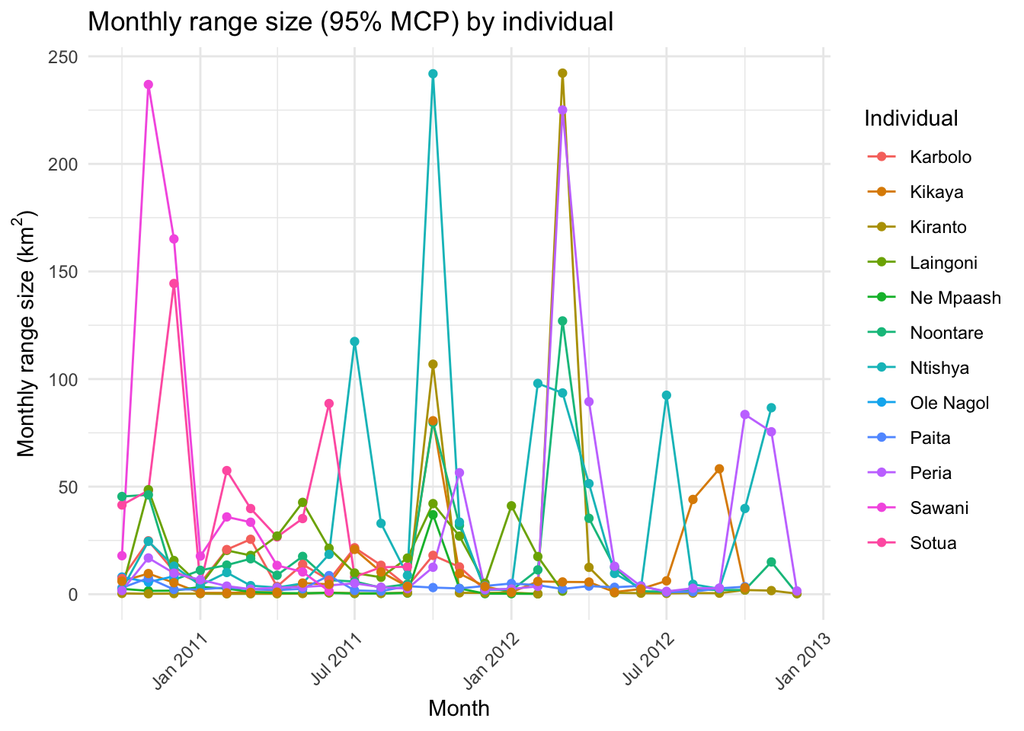

```r
wb_monthly_range_raw %>%
  mutate(area_km2 = area_m2 / 1e6) %>%
  ggplot(aes(x = period, y = area_km2, color = id)) +
  geom_line() +
  geom_point(size = 1.5) +
  scale_x_datetime(date_labels = "%b %Y") +
  theme_minimal() +
  labs(title = "Monthly range size (95% MCP) by individual",
       x = "Month", y = expression("Monthly range size ("*km^2*")"), color = "Individual") +
  theme(axis.text.x = element_text(angle = 45, hjust = 1))
```

> **Discussion:** For a partially migratory population in a seasonal rangeland system, monthly range size is one of the more direct signals of a behavioral shift — a sustained jump in range size points to a wider-ranging or migratory month, while a sustained drop points toward settling into a dry-season refuge or a resource patch. Months with missing points had fewer than 5 fixes that month for that individual, where a 95% MCP isn’t a sensible estimate.

## 5. Intensity of use: how intensively is that area used?

Range size answers “how big an area.” **Intensity of use** answers a different question: within that area, how much ground did the individual actually cover? MoveTraits defines it as the cumulative step distance traveled within a window, divided by the square root of that same window’s home-range area — `path_length / sqrt(area)`. The square root of area gives a characteristic linear scale of the range (think of it as roughly “how wide the range is”), so intensity of use is, loosely, *distance traveled relative to the range’s own width*.

This makes the two traits complementary rather than redundant: an individual could have a *large* range size but *low* intensity of use if it occupies a wide area but moves efficiently within it, or a *small* range size but *high* intensity of use if it covers a lot of relative ground within a compact area — pacing back and forth across a small patch rather than settling into one corner of it.

```r
calc_path_length <- function(track_df, time_unit = "month") {
  track_df %>%
    arrange(t_) %>%
    mutate(period = floor_date(t_, unit = time_unit),
           step = sqrt((x_ - lag(x_))^2 + (y_ - lag(y_))^2)) %>%
    group_by(period) %>%
    summarise(path_length = sum(step, na.rm = TRUE), n_fix = n(), .groups = "drop")
}
```

We reuse the monthly MCP areas already computed in Section 4 (`wb_monthly_range_raw`) rather than recomputing them — the same window, the same area, just paired with cumulative path length instead of summarized on its own:

```r
wb_monthly_path_raw <- trk_nested %>%
  mutate(monthly = map(data, ~ calc_path_length(.x, time_unit = "month"))) %>%
  select(id, monthly) %>%
  unnest(monthly)

wb_monthly_iou_raw <- wb_monthly_path_raw %>%
  left_join(wb_monthly_range_raw %>% select(id, period, area_m2), by = c("id", "period")) %>%
  mutate(iou = path_length / sqrt(area_m2))

wb_monthly_iou <- wb_monthly_iou_raw %>%
  group_by(id) %>%
  summarise(mean_iou   = mean(iou, na.rm = TRUE),
            median_iou = median(iou, na.rm = TRUE),
            cv_iou     = sd(iou, na.rm = TRUE) / mean(iou, na.rm = TRUE),
            p95_iou    = quantile(iou, 0.95, na.rm = TRUE),
            p05_iou    = quantile(iou, 0.05, na.rm = TRUE),
            .groups = "drop")

wb_monthly_iou
```

| id | mean_iou | median_iou | cv_iou | p95_iou | p05_iou |
| --- | --- | --- | --- | --- | --- |
| Karbolo | 39.94194 | 31.70772 | 0.5332994 | 78.50966 | 14.87398 |
| Kikaya | 58.48894 | 52.17252 | 0.4924460 | 110.44737 | 20.28569 |
| Kiranto | 109.94412 | 129.29806 | 0.4354355 | 161.57312 | 18.58141 |
| Laingoni | 36.31082 | 34.66755 | 0.3338333 | 52.37194 | 23.09186 |
| Ne Mpaash | 102.25290 | 97.36024 | 0.4922974 | 168.62099 | 24.67385 |
| Noontare | 41.25195 | 35.61543 | 0.5039124 | 73.90446 | 12.46795 |
| Ntishya | 35.39897 | 31.59407 | 0.5662272 | 71.25381 | 13.41400 |
| Ole Nagol | 40.99298 | 43.48619 | 0.4158445 | 55.33882 | 24.90189 |
| Paita | 57.50067 | 57.90402 | 0.2449379 | 75.21759 | 34.32015 |
| Peria | 40.31321 | 42.98452 | 0.5085994 | 65.34227 | 10.34427 |

[output cut: 2 more lines]

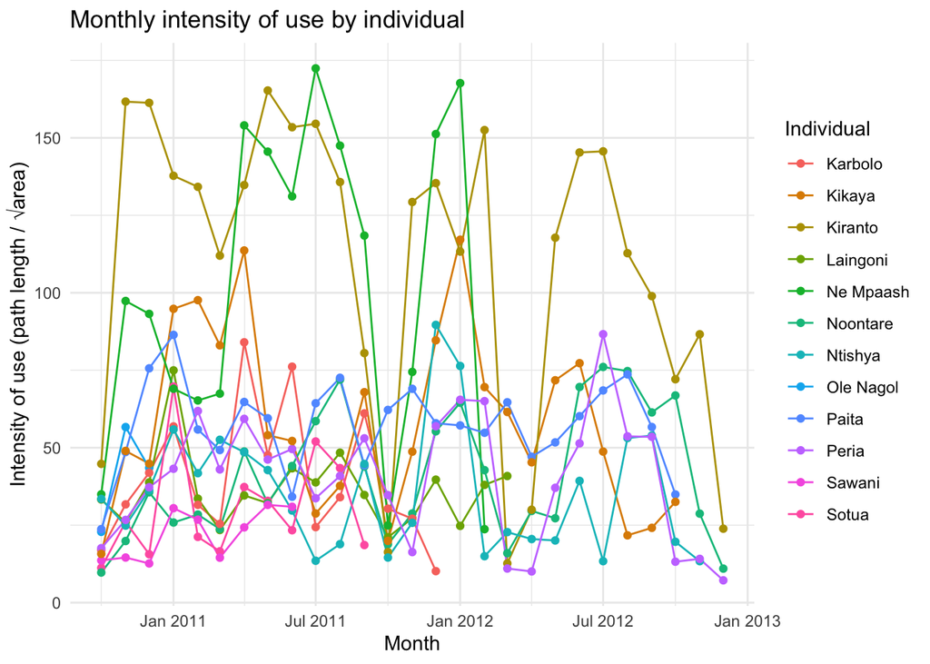

```r
wb_monthly_iou_raw %>%
  ggplot(aes(x = period, y = iou, color = id)) +
  geom_line() +
  geom_point(size = 1.5) +
  scale_x_datetime(date_labels = "%b %Y") +
  theme_minimal() +
  labs(title = "Monthly intensity of use by individual",
       x = "Month", y = "Intensity of use (path length / √area)", color = "Individual")
```

> **Discussion:** Range-size and intensity of use plots can be interpreted together to provide ecological insights. For ungulates in fenced or fragmenting rangelands specifically, a sustained rise in intensity of use without a matching rise in range size can also flag restricted movement — covering more relative ground simply because the available area has shrunk, not because the animal is ranging more widely.

Range size and intensity of use, together with displacement, maximum displacement, and diurnality from the earlier movement-traits module, complete the five-trait set from Beumer et al. (2026). However, these are not the only five metrics that can be used as movement-trait. The database is till actively being developed with new species and new metrics likely to be added in the near future.

## Practice: Apply to your own data

1. **Estimate MCP, LoCoH, and KDE** for one individual in your own dataset with `hr_mcp()`, `hr_locoh()`, `hr_kde()`. Do the three methods agree on area and shape, or diverge the way they did here? If they diverge a lot, what does that tell you about how clustered vs. spread out your animal’s fixes are?
2. **Scale to all individuals** using the nest → map → `bind_rows()` pattern in Section 3. Compare home range area across individuals — and consider whether tracking duration differences are confounding that comparison, the way Section 3’s discussion flags.
3. **Calculate range size and intensity of use** for your own individuals with `calc_range_size()` and `calc_path_length()`. Do individuals separate cleanly by one trait but not the other, the way the discussion in Section 5 anticipates they might?
4. **(Optional, integrative)** Combine range size and intensity of use with displacement, maximum displacement, and diurnality from the earlier movement-traits module into one trait matrix, and rerun that module’s clustering workflow. Does adding these two traits change which individuals group together?

**Useful questions to answer for your own dataset:**

- Does your research question call for a quick, permissive delineation of where the animal could go (MCP), a conservative estimate of core-use area (LoCoH/KDE at 50%), or both?
- Is your tracking duration similar across individuals? If not, how will you account for that before comparing home range area?
- Do range size and intensity of use move together over time for your individuals, or do they decouple — and if they decouple, what’s a plausible ecological explanation (habitat loss, a barrier, a seasonal resource pulse)?

## Key functions reference

| Function | Package | Purpose |
| --- | --- | --- |
| `make_track()` / `transform_coords()` | `amt` | Build a track and reproject it to a metric CRS |
| `hr_mcp()` | `amt` | Minimum convex polygon home range |
| `hr_locoh()` | `amt` | Local convex hull home range |
| `make_trast()` | `amt` | Build a raster template for KDE |
| `hr_kde()` | `amt` | Kernel density estimation home range |
| `hr_area()` | `amt` | Extract area (and isopleth level) from any `amt` home-range object |
| `nest()` / `unnest()` | `tidyr` | Collapse/expand a list-column for per-individual or per-window computation |
| `map()` / `map_dfr()` | `purrr` | Apply a function across a nested list-column, row-binding results |
| `bind_rows()` | `dplyr` | Combine a list of `sf` objects (can’t be `unnest()`-ed directly) |
| `floor_date()` | `lubridate` | Bin timestamps into month/year windows |
| `group_split()` | `dplyr` | Split a grouped data frame into a list of subsets |
| `quantile()` | `stats` | 5th/95th percentile for trait summarization |
| `st_drop_geometry()` | `sf` | Convert an `sf` object to a plain data frame |
| `leaflet()` / `addPolygons()` / `addProviderTiles()` | `leaflet` | Interactive home-range map |

*Next: **[CTMM] Module 2 — Occurrence vs. Range Distributions & Effective Sample Sizes** — having estimated home ranges and two repeated space-use traits under the independence assumption, we turn to `ctmm`, which models the autocorrelation in GPS data directly instead of assuming it away.*